# Problema 4 - Checkpoint 3

```r
library(resample)
```

```
Error in library(resample) : there is no package called 'resample'
```

Continuando a análise anterior, vamos responder mais duas perguntas sobre os dados de commits dos usuários no GitHub.

A primeira pergunta que vamos responder é: Java ou C++ durante a semana?

Essa pergunta pode ajudar a nos mostrar qual dessas duas grandes linguagens OO está mais popular no mercado.

Primeiramento, vamos criar datasets separados para estas duas linguagens.

```r
dados$date <- paste(dados$month_day,dados$the_month, dados$the_year, sep = "-")
dados = dados %>%
  mutate(weekday = weekdays(as.Date(date,'%d-%m-%Y')))
dados = dados %>%
  mutate(isFDS = weekday %in% c("domingo", "sabado"))
dados.java = dados %>% filter(file_extension == "java")
dados.cpp = dados %>% filter(file_extension %in% c("cc", "cpp"))
```

Novamente, como nós estamos trabalhando com uma amostra de dados, vamos aplicar o bootstrapping e calcular o intervalo de confiança.

Para Java, temos o seguinte intervalo de confiança:

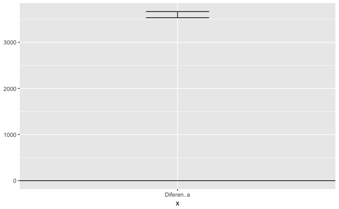

Já para C++:

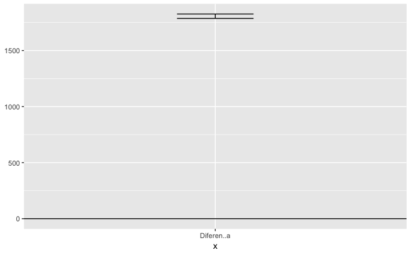

Comoé possível ver, temos dois intervalos de confiança que não se sobrepõe, onde o de Java é 3533-3666 e C++ é 1787-1826. A partir disso, podemos afirmar com 95% de confiança que Java é mais popular do que C++ durante a semana, o que mostra a força de Java no mercado.

Podemos extender um pouco a pergunta e passar pro final de semana. Será que o comportamento se equipara e temos Java como a mais popular das duas no final de semana também?

Para Java:

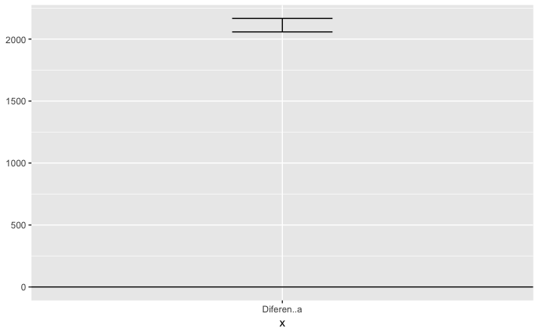

Para C++:

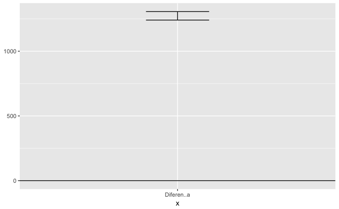

Mais uma vez, podemos ver pelos gráficos que o intervalo de confiança de Java e C++ não tem interseção, logo há uma diferença considerável entre ambos, com Java mais uma vez sendo mais popular que C++.